# Web Mining and Applied NLP (44-620)

## Web Scraping and NLP with Requests, BeautifulSoup, and spaCy

### Student Name: Arnold Atchoe.

### Repository link: https://github.com/kwameape123/620-mod6-web-scraping

Perform the tasks described in the Markdown cells below. When you have completed the assignment make sure your code cells have all been run (and have output beneath them) and ensure you have committed and pushed ALL of your changes to your assignment repository.

Every question that requires you to write code will have a code cell underneath it; you may either write your entire solution in that cell or write it in a python file (`.py`), then import and run the appropriate code to answer the question.

### STEP 1: VERIFY IF RELEVANT LIBRARIES ARE INSTALLED.

```python
%pip install beautifulsoup4 html5lib ipykernel jupyterlab matplotlib requests spacy spacytextblob
```

[output not shown]

[output cut: 194 more lines]

[output not shown]

### STEP 2: IMPORT PYTHON LIBRARIES SPECIFIC TO THIS PROJECT.

```python
from bs4 import BeautifulSoup
import requests
import matplotlib.pyplot as plt
import spacy
import spacytextblob
import pickle
```

### STEP 3(QUESTION 1): SAVE WEB PAGE ARTICLE AS A FILE.

Write code that extracts the article html from https://web.archive.org/web/20210327165005/https://hackaday.com/2021/03/22/how-laser-headlights-work/ and dumps it to a .pkl (or other appropriate file)

```python
# Use requests to fetch the web page
url = 'https://web.archive.org/web/20210327165005/https://hackaday.com/2021/03/22/how-laser-headlights-work/'
article = requests.get(url)

# View the status code to ensure the request was successful
if article.status_code == 200:
    print("web page fetched successfully.")
else:print(f"fetch error, status code: {article.status_code}")

# View the content type to ensure it's HTML
print("Content type:", article.headers['Content-Type'])

# View the html content
article_content = article.text
print(article_content)

# save the article html to a pickle file
with open('article.pkl', 'wb') as file:
    pickle.dump(article_content, file)

# or save the article html to a text file
with open('article.txt', 'w', encoding='utf-8') as file:
    file.write(article_content)

# Note that beautifulsoup4 can read either the pickle file or the text file
```

[output not shown]

[output cut: 4140 more lines]

[output not shown]

### STEP 4(QUESTION 2): READ ARTICLE HTML FROM FILE AND PRINT TEXT CONTENT.

Read in your article's html source from the file you created in question 1 and print it's text (use `.get_text()`)

```python
# The text of the article is in the article element
# read the article html from the pickle file
with open('article.pkl', 'rb') as file:
    article_html1 = pickle.load(file)

# read the article html from the text file
with open('article.txt', 'r', encoding='utf-8') as file:
    article_html2 = file.read()

# Create a BeautifulSoup object
soup1 = BeautifulSoup(article_html1, 'html5lib')
soup2 = BeautifulSoup(article_html2, 'html5lib')

# Find the article element
article_element1 = soup1.find('article')
article_element2 = soup2.find('article')

# Print the first 3000 characters of article text to verify
# that the content is correctly loaded from both files
print("Article text from pickle file:")
print(article_element1.get_text()[:3000])
print()  # Print an empty line
print("Article text from text file:")
print(article_element2.get_text()[:3000])
```

```
Article text from pickle file:


        How Laser Headlights Work


                130 Comments

                by:
                Lewin Day




            March 22, 2021










        When we think about the onward march of automotive technology, headlights aren’t usually the first thing that come to mind. Engines, fuel efficiency, and the switch to electric power are all more front of mind. However, that doesn’t mean there aren’t thousands of engineers around the world w…
Sealed beam headlights gave way to more modern designs once regulations loosened up, while bulbs moved from simple halogens to xenon HIDs and, more recently, LEDs. Now, a new technology is on the scene, with lasers!

Laser Headlights?!
BWM’s prototype laser headlight assemblies undergoing testing.
The first image brought to mind by the phrase “laser headlights” is that of laser beams firing out the front of an automobile. Obviously, coherent beams of monochromatic light would make for poor illumination outside of a very specific spot quite some distance away. Thankfully for our eyes, laser he…
Instead, laser headlights consist of one or more solid state laser diodes mounted inside the headlight. These blue lasers are fired at a yellow phosphor, similar to that used in white LEDs. This produces a powerful, vibrant white light that can then be bounced off reflectors and out of the headlight…
BWM’s futuristic i8 was one of the first vehicles to ship with laser headlight technology.
Laser headlights are still a nascent technology, thus far only appearing in a few BMW, Audi, and other select vehicles. BMW’s technology was developed in partnership with lighting experts OSRAM. In practice, a regular LED low-beam lamp is used, with the laser used to create an incredibly bright and …

Article text from text file:


        How Laser Headlights Work

```

[output cut: 14 more lines]

```






        When we think about the onward march of automotive technology, headlights aren’t usually the first thing that come to mind. Engines, fuel efficiency, and the switch to electric power are all more front of mind. However, that doesn’t mean there aren’t thousands of engineers around the world w…
Sealed beam headlights gave way to more modern designs once regulations loosened up, while bulbs moved from simple halogens to xenon HIDs and, more recently, LEDs. Now, a new technology is on the scene, with lasers!

Laser Headlights?!
BWM’s prototype laser headlight assemblies undergoing testing.
The first image brought to mind by the phrase “laser headlights” is that of laser beams firing out the front of an automobile. Obviously, coherent beams of monochromatic light would make for poor illumination outside of a very specific spot quite some distance away. Thankfully for our eyes, laser he…
Instead, laser headlights consist of one or more solid state laser diodes mounted inside the headlight. These blue lasers are fired at a yellow phosphor, similar to that used in white LEDs. This produces a powerful, vibrant white light that can then be bounced off reflectors and out of the headlight…
BWM’s futuristic i8 was one of the first vehicles to ship with laser headlight technology.
Laser headlights are still a nascent technology, thus far only appearing in a few BMW, Audi, and other select vehicles. BMW’s technology was developed in partnership with lighting experts OSRAM. In practice, a regular LED low-beam lamp is used, with the laser used to create an incredibly bright and …
```

### STEP 5(QUESTION 3): TOKENIZATION OF ARTICLE TEXT.

Load the article text into a trained `spaCy` pipeline, and determine the 5 most frequent tokens (converted to lower case). Print the common tokens with an appropriate label. Additionally, print the tokens their frequencies (with appropriate labels). Make sure to remove things we don't care about (punctuation, stopwords, whitespace).

```python
from collections import Counter
# Load the spaCy model
nlp = spacy.load("en_core_web_sm")


# Process the article text
doc1 = nlp(article_element1.get_text())
doc2 = nlp(article_element2.get_text())

# Get the tokens from the article text,converting to lower case and removing punctuation, stopwords, and whitespace
# for both the pickle file and the text file
tokens1 = [token.text.lower() for token in doc1 if not token.is_punct and not token.is_stop and not token.is_space]
tokens2 = [token.text.lower() for token in doc2 if not token.is_punct and not token.is_stop and not token.is_space]

# Count the frequency of each token
token_freq1 = Counter(tokens1)
token_freq2 = Counter(tokens2)

# print tokens and their frequencies for the first 5 most common tokens
common_tokens1 = token_freq1.most_common(5)
common_tokens2 = token_freq2.most_common(5)
print("5 Most frequent tokens from pickle file:")
for token, freq in common_tokens1:
    print(f"Token: {token}, Frequency: {freq}")
print()  # Print an empty line
print("5 Most frequent tokens from text file:")
for token, freq in common_tokens2:
    print(f"Token: {token}, Frequency: {freq}")
```

```
5 Most frequent tokens from pickle file:
Token: laser, Frequency: 35
Token: headlights, Frequency: 19
Token: headlight, Frequency: 11
Token: technology, Frequency: 10
Token: led, Frequency: 10

5 Most frequent tokens from text file:
Token: laser, Frequency: 35
Token: headlights, Frequency: 19
Token: headlight, Frequency: 11
Token: technology, Frequency: 10
Token: led, Frequency: 10
```

### STEP 6(QUESTION 4): LEMMATIZATION OF ARTICLE TEXT

Load the article text into a trained `spaCy` pipeline, and determine the 5 most frequent lemmas (converted to lower case). Print the common lemmas with an appropriate label. Additionally, print the lemmas with their frequencies (with appropriate labels). Make sure to remove things we don't care about (punctuation, stopwords, whitespace).

```python
from collections import Counter
# Load the spaCy model
nlp = spacy.load("en_core_web_sm")


# Process the article text
doc1 = nlp(article_element1.get_text())
doc2 = nlp(article_element2.get_text())

# get the lemmas from the article text, converting to lower case and removing punctuation, stopwords, and whitespace
# for both the pickle file and the text file
lemmas1 = [token.lemma_.lower() for token in doc1 if not token.is_punct and not token.is_stop and not token.is_space]
lemmas2 = [token.lemma_.lower() for token in doc2 if not token.is_punct and not token.is_stop and not token.is_space]

# Count the frequency of each lemma
lemma_freq1 = Counter(lemmas1)
lemma_freq2 = Counter(lemmas2)

# print lemmas and their frequencies for the first 5 most common lemmas
common_lemmas1 = lemma_freq1.most_common(5)
common_lemmas2 = lemma_freq2.most_common(5)
print("5 Most frequent lemmas from pickle file:")
for lemma, freq in common_lemmas1:
    print(f"Lemma: {lemma}, Frequency: {freq}")
print()  # Print an empty line
print("5 Most frequent lemmas from text file:")
for lemma, freq in common_lemmas2:
    print(f"Lemma: {lemma}, Frequency: {freq}")
```

```
5 Most frequent lemmas from pickle file:
Lemma: laser, Frequency: 40
Lemma: headlight, Frequency: 28
Lemma: beam, Frequency: 12
Lemma: technology, Frequency: 10
Lemma: led, Frequency: 10

5 Most frequent lemmas from text file:
Lemma: laser, Frequency: 40
Lemma: headlight, Frequency: 28
Lemma: beam, Frequency: 12
Lemma: technology, Frequency: 10
Lemma: led, Frequency: 10
```

### STEP 7(QUESTION 5)

Define the following methods: * `score_sentence_by_token(sentence, interesting_token)` that takes a sentence and a list of interesting token and returns the number of times that any of the interesting words appear in the sentence divided by the number of words in the sentence * `score_sentence_by_lemma(sentence, interesting_lemmas)` that takes a sentence and a list of interesting lemmas and returns the number of times that any of the interesting lemmas appear in the sentence divided by the number of words in the sentence

You may find some of the code from the in class notes useful; feel free to use methods (rewrite them in this cell as well). Test them by showing the score of the first sentence in your article using the frequent tokens and frequent lemmas identified in question 3.

```python
import string

def score_sentence_by_token(sentence, interesting_token):
    """
    Score a sentence based on the presence of interesting tokens.

    Args:
        sentence (str): The sentence to score.
        interesting_token (list): A list of interesting tokens.

    Returns:
        float: The score of the sentence.
    """
    translator = str.maketrans('', '', string.punctuation)  # Remove punctuation
    cleaned_sentence = sentence.translate(translator)  # Clean the sentence
    cleaned_sentence = cleaned_sentence.lower()  # Convert to lower case
    print(f"Cleaned sentence: {cleaned_sentence}")  # Debugging line to check cleaned sentence
    # Split the cleaned sentence into words
    words = cleaned_sentence.split()
    print(f"Words in sentence: {words}")  # Debugging line to check words
    # Check if there are any words in the sentence
    if len(words) == 0:
        return 0.0
    count = sum(1 for word in words if word.lower() in interesting_token)
    print(f"Count of interesting tokens in sentence: {count}")  # Debugging line to check count
    print(f"Total words in sentence: {len(words)}")  # Debugging line
    return round(count / len(words),5)

def score_sentence_by_lemma(sentence, interesting_lemmas):
    """
    Score a sentence based on the presence of interesting lemmas.

    Args:
        sentence (str): The sentence to score.
        interesting_lemmas (list): A list of interesting lemmas.

    Returns:
        float: The score of the sentence.
    """
    translator = str.maketrans('', '', string.punctuation)  # Remove punctuation
    cleaned_sentence = sentence.translate(translator)  # Clean the sentence
    cleaned_sentence = cleaned_sentence.lower()  # Convert to lower case
    print(f"Cleaned sentence: {cleaned_sentence}")  # Debugging line to check cleaned sentence
    # Split the cleaned sentence into words
    words = cleaned_sentence.split()
    print(f"Words in sentence: {words}")  # Debugging line to check words
    # Check if there are any words in the sentence
    if len(words) == 0:
        return 0.0
    count = sum(1 for word in words if word.lower() in interesting_lemmas)
    print(f"Count of interesting lemmas in sentence: {count}")  # Debugging line to check count
    print(f"Total words in sentence: {len(words)}")  # Debugging line
    return round(count / len(words), 5)

# Example usage
initial_paragraph= article_element1.find('p').get_text()  # Get the first paragraph of the article
first_sentence = initial_paragraph.split('.')[0]  # Get the first sentence
print("First sentence:", first_sentence)  # Print the first sentence
sentence = first_sentence.strip()  # Remove leading/trailing whitespace
# Extract just the tokens (without frequencies) from the common_tokens1 list
interesting_tokens = [token for token, freq in common_tokens1]  # Use the first 5 common tokens from the pickle file
print("Interesting tokens:", interesting_tokens)  # Print the interesting tokens
interesting_lemmas = [lemma for lemma, freq in common_lemmas1]  # Use the first 5 common lemmas from the pickle file
print("Interesting lemmas:", interesting_lemmas)  # Print the interesting lemmas
print(score_sentence_by_token(sentence, interesting_tokens))  # Score by token
print(score_sentence_by_lemma(sentence, interesting_lemmas))  # Score by lemma string
```

```
First sentence: When we think about the onward march of automotive technology, headlights aren’t usually the first thing that come to mind
Interesting tokens: ['laser', 'headlights', 'headlight', 'technology', 'led']
Interesting lemmas: ['laser', 'headlight', 'beam', 'technology', 'led']
Cleaned sentence: when we think about the onward march of automotive technology headlights aren’t usually the first thing that come to mind
Words in sentence: ['when', 'we', 'think', 'about', 'the', 'onward', 'march', 'of', 'automotive', 'technology', 'headlights', 'aren’t', 'usually', 'the', 'first', 'thing', 'that', 'come', 'to', 'mind']
Count of interesting tokens in sentence: 2
Total words in sentence: 20
0.1
Cleaned sentence: when we think about the onward march of automotive technology headlights aren’t usually the first thing that come to mind
Words in sentence: ['when', 'we', 'think', 'about', 'the', 'onward', 'march', 'of', 'automotive', 'technology', 'headlights', 'aren’t', 'usually', 'the', 'first', 'thing', 'that', 'come', 'to', 'mind']
Count of interesting lemmas in sentence: 1
Total words in sentence: 20
0.05
```

### STEP 8(QUESTION 6)

Make a list containing the scores (using tokens) of every sentence in the article, and plot a histogram with appropriate titles and axis labels of the scores. From your histogram, what seems to be the most common range of scores (put the answer in a comment after your code)?

[output not shown]

[output cut: 237 more lines]

[output not shown]

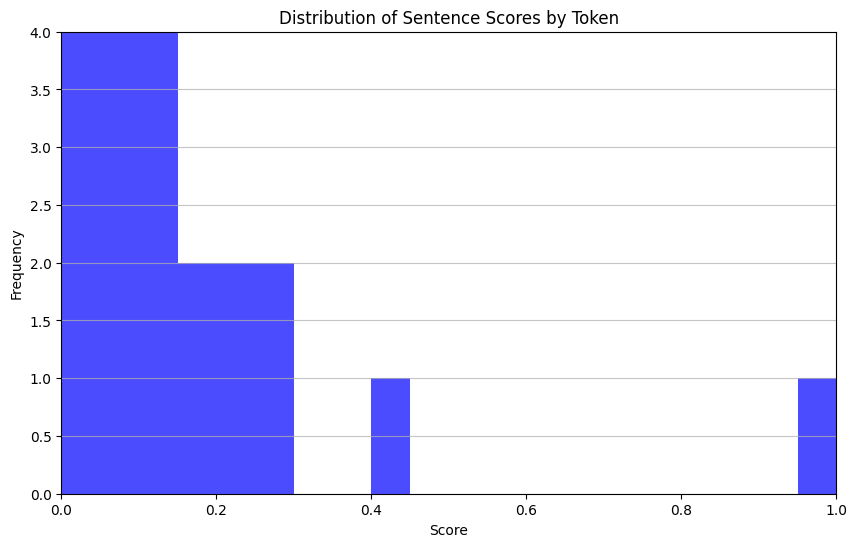

```python
#use the same methods to score every sentence in the article
def score_article_by_token(article_text, interesting_tokens):
    """
    Score an article based on the presence of interesting tokens in each sentence.

    Args:
        article_text (str): The text of the article.
        interesting_tokens (list): A list of interesting tokens.

    Returns:
        list: A list of scores for each sentence in the article.
    """
    doc = nlp(article_text)
    scores = []
    for sent in doc.sents:
        score = score_sentence_by_token(sent.text, interesting_tokens)

        scores.append(score)
    return scores


scores = score_article_by_token(article_element1.get_text(), interesting_tokens)


# plot on histogram the scores for each sentence
plt.figure(figsize=(10, 6))
plt.hist(scores, bins=20, color='blue', alpha=0.7)
plt.title("Distribution of Sentence Scores by Token")
plt.xlabel('Score')
plt.ylabel('Frequency')
plt.grid(axis='y', alpha=0.75)
plt.ylim(0,4)
plt.xlim(0, 1)
plt.show()

# Answer: From the histogram, we can see that the most common range of scores 0 and 0.1.
```

#### Answer:

From the histogram, we can see that the most common range of scores 0 and 0.1.

### STEP 9(QUESTION 7)

Make a list containing the scores (using lemmas) of every sentence in the article, and plot a histogram with appropriate titles and axis labels of the scores. From your histogram, what seems to be the most common range of scores (put the answer in a comment after your code)?

[output not shown]

[output cut: 237 more lines]

[output not shown]

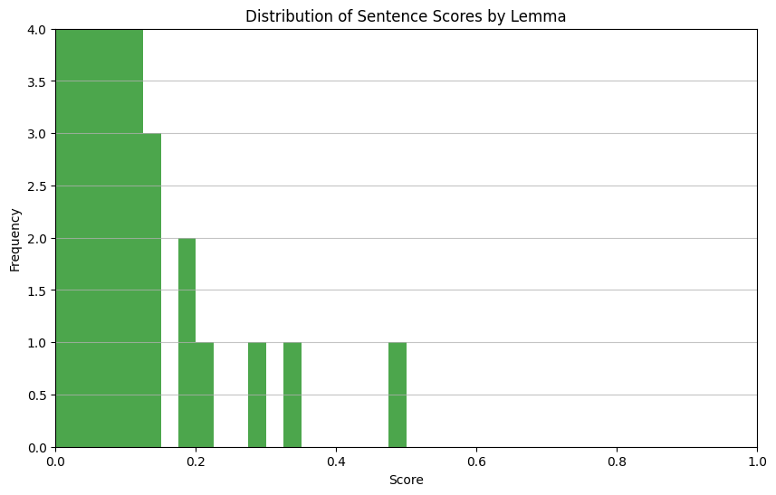

```python
# perform the same operation for the lemmas
def score_article_by_lemma(article_text, interesting_lemmas):
    """
    Score an article based on the presence of interesting lemmas in each sentence.

    Args:
        article_text (str): The text of the article.
        interesting_lemmas (list): A list of interesting lemmas.

    Returns:
        list: A list of scores for each sentence in the article.
    """
    doc = nlp(article_text)
    scores = []
    for sent in doc.sents:
        score = score_sentence_by_lemma(sent.text, interesting_lemmas)
        scores.append(score)
    return scores
scores_lemmas = score_article_by_lemma(article_element1.get_text(), interesting_lemmas)
# plot on histogram the scores for each sentence
plt.figure(figsize=(10, 6))
plt.hist(scores_lemmas, bins=20, color='green', alpha=0.7)
plt.title("Distribution of Sentence Scores by Lemma")
plt.xlabel('Score')
plt.ylabel('Frequency')
plt.grid(axis='y', alpha=0.75)
plt.ylim(0,4)
plt.xlim(0, 1)
plt.show()

# Answer: From the histogram, we can see that the most common range of scores 0 and 0.1.
```

#### Answer:

From the histogram, we can see that the most common range of scores 0 and 0.1.

### STEP 10(QUESTION 8)

Which tokens and lexems would be ommitted from the lists generated in questions 3 and 4 if we only wanted to consider nouns as interesting words? How might we change the code to only consider nouns? Put your answer in this Markdown cell (you can edit it by double clicking it).

#### Answer:

Based on my analysis in question 3 and 4, no word in the most common tokens and lemmas would be ommitted since they are all nouns. How ever if we want to exclude non-nouns, we can filter tokens and lemmas based on their part-of-speech tags. An example of a code we can utilize is:

`common_tokens_nouns = [token for token, freq in common_tokens1 if nlp.vocab[token].pos_ == 'NOUN']` `common_lemmas_nouns = [lemma for lemma, freq in common_lemmas1 if nlp.vocab[lemma].pos_ == 'NOUN']`